# Final Project: Investigating Thyroid Function

### Main effects and second order interactions

```r
fit_main_step <- glm(has_hypothyroidism ~ (.)^2, family = binomial(), data = training)

fit_step1 <- step(fit_null, scope=list(lower=fit_null,upper=fit_main_step),direction="both")
```

```
## Start:  AIC=626.1
## has_hypothyroidism ~ 1
##
##                 Df Deviance    AIC
## + t4_medication  1   561.58 565.58
## + t4_free_value  1   602.93 606.93
## + t4_value       1   617.21 621.21
## + gender         1   619.90 623.90
## + age            1   621.60 625.60
## <none>               624.10 626.10
## + t3_value       1   622.17 626.17
## + t3_medication  1   624.04 628.04
##
## Step:  AIC=565.58
## has_hypothyroidism ~ t4_medication
##
##                 Df Deviance    AIC
## + t4_free_value  1   548.83 554.83
## <none>               561.58 565.58
## + age            1   560.33 566.33
## + t4_value       1   560.40 566.40
## + gender         1   560.79 566.79
## + t3_value       1   561.18 567.18
## + t3_medication  1   561.53 567.53
## - t4_medication  1   624.10 626.10
##
## Step:  AIC=554.83
## has_hypothyroidism ~ t4_medication + t4_free_value
##
##                               Df Deviance    AIC
## + t3_value                     1   545.55 553.55
## + age                          1   545.97 553.97
## <none>                             548.83 554.83
## + t4_value                     1   548.13 556.13
## + gender                       1   548.14 556.14
## + t4_free_value:t4_medication  1   548.35 556.35
## + t3_medication                1   548.79 556.79
## - t4_free_value                1   561.58 565.58
## - t4_medication                1   602.93 606.93
##
```

[output cut: 38 more lines]

```
##     age + t3_value:age
##
##                               Df Deviance    AIC
## <none>                             537.68 549.68
## - t3_value:age                 1   539.72 549.72
## + t4_free_value:t4_medication  1   537.23 551.23
## + gender                       1   537.24 551.24
## + t4_free_value:age            1   537.35 551.35
## + t4_value                     1   537.53 551.53
## + t3_value:t4_medication       1   537.57 551.57
## + t3_medication                1   537.58 551.58
## + t3_value:t4_free_value       1   537.58 551.58
## + age:t4_medication            1   537.68 551.68
## - t4_free_value                1   557.04 567.04
## - t4_medication                1   594.50 604.50
```

```r
summary(fit_step1)
```

```
##
## Call:
## glm(formula = has_hypothyroidism ~ t4_medication + t4_free_value +
##     t3_value + age + t3_value:age, family = binomial(), data = training)
##
## Deviance Residuals:
##     Min       1Q   Median       3Q      Max
## -1.8711  -0.8940  -0.6063   0.9567   2.2968
##
## Coefficients:
##                    Estimate Std. Error z value Pr(>|z|)
## (Intercept)      -2.4808627  1.0604000  -2.340   0.0193 *
## t4_medicationYes  1.5771901  0.2175366   7.250 4.16e-13 ***
## t4_free_value    -1.3277137  0.3212050  -4.134 3.57e-05 ***
## t3_value          0.0280174  0.0122278   2.291   0.0219 *
## age               0.0355704  0.0162857   2.184   0.0290 *
## t3_value:age     -0.0002851  0.0001997  -1.428   0.1534
## ---
## Signif. codes:  0 '***' 0.001 '**' 0.01 '*' 0.05 '.' 0.1 ' ' 1
##
## (Dispersion parameter for binomial family taken to be 1)
##
##     Null deviance: 624.10  on 454  degrees of freedom
## Residual deviance: 537.68  on 449  degrees of freedom
## AIC: 549.68
##
## Number of Fisher Scoring iterations: 4
```

```r
pR2(fit_step1)
```

```
## fitting null model for pseudo-r2
```

```
##          llh      llhNull           G2     McFadden         r2ML         r2CU
## -268.8387848 -312.0496483   86.4217271    0.1384743    0.1729895    0.2317927
```

#### Removing insignifcant variable age:t3_value which has p-value equal to 0.1534 (Significance level = 0.05):

```r
fit_main_step2 <- glm(formula = has_hypothyroidism ~ t4_medication + t4_free_value +
    age + t3_value, family = binomial(), data = training)

summary(fit_main_step2)
```

```
##
## Call:
## glm(formula = has_hypothyroidism ~ t4_medication + t4_free_value +
##     age + t3_value, family = binomial(), data = training)
##
## Deviance Residuals:
##     Min       1Q   Median       3Q      Max
## -1.7350  -0.8867  -0.6084   0.9669   2.1414
##
## Coefficients:
##                   Estimate Std. Error z value Pr(>|z|)
## (Intercept)      -1.211778   0.578497  -2.095   0.0362 *
## t4_medicationYes  1.576917   0.217015   7.266 3.69e-13 ***
## t4_free_value    -1.329716   0.319465  -4.162 3.15e-05 ***
## age               0.013972   0.005886   2.374   0.0176 *
## t3_value          0.011998   0.004836   2.481   0.0131 *
## ---
## Signif. codes:  0 '***' 0.001 '**' 0.01 '*' 0.05 '.' 0.1 ' ' 1
##
## (Dispersion parameter for binomial family taken to be 1)
##
##     Null deviance: 624.10  on 454  degrees of freedom
## Residual deviance: 539.72  on 450  degrees of freedom
## AIC: 549.72
##
## Number of Fisher Scoring iterations: 4
```

```r
pR2(fit_main_step2)
```

```
## fitting null model for pseudo-r2
```

```
##          llh      llhNull           G2     McFadden         r2ML         r2CU
## -269.8586864 -312.0496483   84.3819238    0.1352059    0.1692736    0.2268137
```

McFadden: 0.1352059  
r2CU: 0.2268137  
AIC: 549.72

## Equation for fitted coefficients

logit(has_hypothyroidism) = (t4_medicationYes * 1.576917) + (t4_free_value * -1.329716) + (age * 0.013972) + (t3_value * 0.011998) - 1.211778

## Effect of significant variables on has_hypothyroidism variable

For every one-unit (years) increase in age, the odds of having hypothyroidism is multiplied by exp(0.013972) = 1.01407 (ie: an increase of 1.41%) on average, when all other variables in the model are held constant.

For every one-unit (ng/dL) increase in T3 value, the odds of having hypothyroidism is multiplied by exp(0.011998) = 1.01207 (ie: an increase of 1.21%) on average, when all other variables in the model are held constant.

#### Predicting on test data:

```r
pred_log <- predict(fit_main_step2, testing, type="response")
print(pred_log)
```

```
##          6         46         55         93        101        142        151
## 0.24928037 0.09126014 0.25064125 0.16282623 0.01757650 0.34236846 0.60985332
##        159        265        368        371        468        490        542
## 0.22994972 0.60291005 0.34600802 0.50497974 0.65886800 0.24901124 0.28277249
##        671        683        808        810        827        891        902
## 0.33648561 0.23254085 0.68667928 0.62722734 0.26013993 0.53805200 0.09934576
##        936        971       1228       1230       1274       1299       1423
## 0.18095306 0.53282135 0.70541860 0.25715089 0.12537288 0.20195143 0.53604755
##       1492       1529       1587       1621       1810       1844       1888
## 0.57188914 0.72469223 0.41737710 0.70101149 0.20517687 0.35162314 0.63190555
##       1967       1991       2164       2242       2253       2293       2396
## 0.71888894 0.75041540 0.47989004 0.52273027 0.29140316 0.68484049 0.74925196
##       2426       2475       2489       2524       2565       2600       2648
## 0.76553624 0.55706718 0.23780049 0.51399213 0.57681150 0.57499226 0.24354043
##       2762       2766       2777       2846       2864       2945       3051
## 0.15244018 0.46212368 0.29676275 0.16469611 0.13394034 0.75812974 0.23487915
##       3070       3075       3176       3191       3192       3391       3431
## 0.68819797 0.31741115 0.21360804 0.27491231 0.21009697 0.35135639 0.28787558
##       3443       3448       3699       3767       3858       3884       4020
## 0.72522310 0.74437553 0.78632455 0.29610939 0.49164006 0.59088833 0.28217846
##       4067       4076       4117       4159       4176       4186       4207
## 0.73882537 0.31513608 0.38080711 0.71512125 0.66895352 0.75321280 0.28171192
##       4251       4284       4372       4403       4443       4502       4507
## 0.29508040 0.67749922 0.26216753 0.17411571 0.24236459 0.27824058 0.32312557
##       4536       4537       4615       4654       4816       4852       4909
## 0.75430462 0.34830564 0.81706475 0.33668725 0.30953354 0.18782014 0.63545021
##       4958       5032       5061       5125       5133       5215       5228
## 0.72991635 0.37459801 0.34821616 0.78468922 0.73379551 0.70868759 0.46250488
##       5232       5252       5276       5306       5596       5762       5786
## 0.26620094 0.68386637 0.18680558 0.39227155 0.70629939 0.56402900 0.10481295
##       5858       5917       6005       6030       6097       6175       6221
## 0.72611327 0.27738715 0.78714741 0.51003970 0.36702715 0.32585595 0.14721670
##       6246       6297       6566       6606       6835       6880       6956
## 0.78727741 0.14489887 0.44189231 0.46635122 0.62760516 0.56822120 0.42657576
##       7101       7195       7204       7211       7261       7347       7362
## 0.59708040 0.25162097 0.25855427 0.61520399 0.73439437 0.70603514 0.18656731
##       7381       7452       7553       7602       7677       7704       7726
## 0.15776920 0.21337226 0.20887998 0.19510210 0.36211726 0.20083708 0.35141738
##       7764       7854       7879       8024       8045       8110       8271
## 0.77502975 0.69390853 0.27148814 0.42511531 0.17402037 0.41601945 0.33875577
##       8272       8288       8303       8363       8381       8387       8434
## 0.78834194 0.35239322 0.73229755 0.10702634 0.34345041 0.56592931 0.48631624
##       8456       8549       8564       8621       8755       8798       8843
## 0.43951500 0.64270055 0.30616291 0.32558743 0.32672143 0.34835470 0.58965926
##       8868       8998       9046       9128       9162       9399       9451
## 0.55069370 0.70128359 0.70486527 0.12795528 0.86831554 0.25203635 0.27013530
##       9659       9674       9750       9769       9794       9832       9908
## 0.33714289 0.23678854 0.20887585 0.25586341 0.67841690 0.70691462 0.31489150
##       9946      10093      10098      10255      10360      10376      10450
## 0.14672325 0.29041781 0.76041374 0.60100526 0.69426832 0.80294107 0.57618659
##      10573      10853      10890      10990      11040      11081      11085
## 0.53102028 0.65676381 0.60919888 0.82210796 0.27237592 0.62221641 0.66819174
##      11200      11225      11268      11296      11454      11482      11527
## 0.53586326 0.60523444 0.23838062 0.22392474 0.23753757 0.22222906 0.65177353
##      11621      12047      12057      12104      12128
## 0.43267438 0.21072761 0.55527034 0.42873931 0.53129942
```

#### Displaying confusion matrix:

```r
confusionMatrix(data = as.factor(as.numeric(pred_log > 0.5)), reference = testing$has_hypothyroidism, positive = "1")
```

```
## Confusion Matrix and Statistics
##
##           Reference
## Prediction  0  1
##          0 86 24
##          1 23 61
##
##                Accuracy : 0.7577
##                  95% CI : (0.6912, 0.8162)
##     No Information Rate : 0.5619
##     P-Value [Acc > NIR] : 1.112e-08
##
##                   Kappa : 0.5073
##
##  Mcnemar's Test P-Value : 1
##
##             Sensitivity : 0.7176
##             Specificity : 0.7890
##          Pos Pred Value : 0.7262
##          Neg Pred Value : 0.7818
##              Prevalence : 0.4381
##          Detection Rate : 0.3144
##    Detection Prevalence : 0.4330
##       Balanced Accuracy : 0.7533
##
##        'Positive' Class : 1
##
```

Accuracy : 0.7577  
Sensitivity : 0.7176  
Specificity : 0.7890

#### ROC:

```r
logROC <- roc(testing$has_hypothyroidism, predict(fit_main_step2, testing, type = "response"))
```

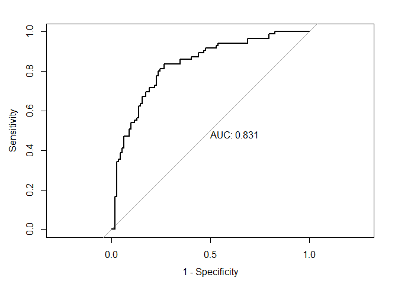

```r
plot.roc(logROC, print.auc=TRUE, legacy.axes=TRUE)
```

AUC = 0.831

#### Predicted vs Actual values plot:

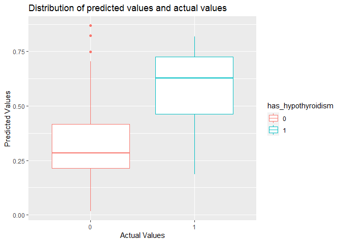

```r
g13 <- ggplot(testing)
g13 + geom_boxplot(aes(x = has_hypothyroidism, y = pred_log, color = has_hypothyroidism))+
  ggtitle("Distribution of predicted values and actual values") +
  xlab("Actual Values") + ylab("Predicted Values")
```

# SVM

#### Converting response variable into “No” for 0 and “Yes” for 1:

```r
levels(training$has_hypothyroidism) <- c("No", "Yes")
levels(testing$has_hypothyroidism) <- c("No", "Yes")
```

### With Linear kernel

```r
trctrl <- trainControl(summaryFunction=twoClassSummary,classProbs = TRUE, method = "repeatedcv", number = 10, repeats = 10)

grid <- expand.grid(C = c(0.005,0.01, 0.05, 0.1, 0.25, 0.5, 0.75, 1, 1.25, 1.5, 1.75, 2,5))

set.seed(300)
svm_Linear <- train(has_hypothyroidism ~., data = training,
                    method = "svmLinear",
                    trControl=trctrl,
                    preProcess = c("center", "scale"),
                    metric="ROC",
                    tuneGrid = grid,
                    tuneLength = 10)
print(svm_Linear)
```

```
## Support Vector Machines with Linear Kernel
##
## 455 samples
##   7 predictor
##   2 classes: 'No', 'Yes'
##
## Pre-processing: centered (7), scaled (7)
## Resampling: Cross-Validated (10 fold, repeated 10 times)
## Summary of sample sizes: 410, 409, 409, 410, 409, 410, ...
## Resampling results across tuning parameters:
##
##   C      ROC        Sens       Spec
##   0.005  0.7149754  0.7140462  0.65
##   0.010  0.7184446  0.7175538  0.65
##   0.050  0.7025715  0.7175538  0.65
##   0.100  0.7089746  0.7175538  0.65
##   0.250  0.7082777  0.7175538  0.65
##   0.500  0.7166877  0.7175538  0.65
##   0.750  0.7125508  0.7175538  0.65
##   1.000  0.7118654  0.7175538  0.65
##   1.250  0.7104662  0.7175538  0.65
##   1.500  0.7146715  0.7175538  0.65
##   1.750  0.7175877  0.7175538  0.65
##   2.000  0.7126338  0.7175538  0.65
##   5.000  0.7111708  0.7175538  0.65
##
## ROC was used to select the optimal model using the largest value.
## The final value used for the model was C = 0.01.
```

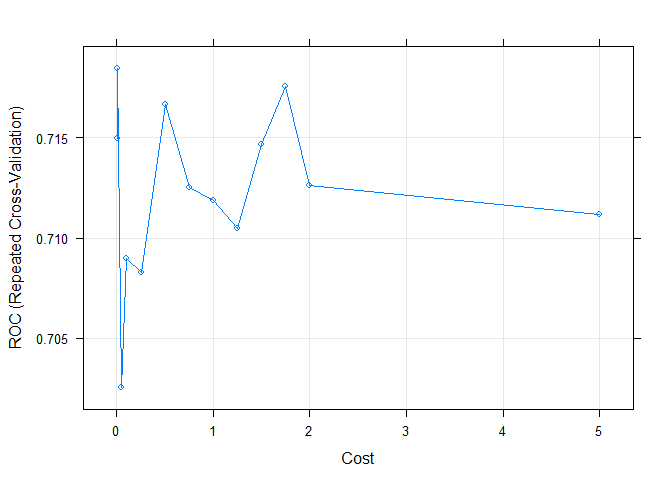

```r
plot(svm_Linear)
```

#### Prediction on testing data:

```r
pred_svmLinear <- predict(svm_Linear, newdata = testing)
print(pred_svmLinear)
```

```
##   [1] No  No  No  No  No  No  Yes Yes Yes No  No  Yes No  No  No  No  Yes Yes
##  [19] No  Yes No  No  Yes Yes No  No  No  Yes Yes Yes No  Yes No  No  Yes Yes
##  [37] Yes No  Yes No  Yes Yes Yes Yes No  Yes Yes Yes No  No  No  No  No  No
##  [55] Yes No  Yes No  No  No  No  No  No  Yes Yes Yes No  Yes Yes No  Yes No
##  [73] No  Yes Yes Yes No  No  Yes No  No  No  No  No  Yes No  Yes No  No  Yes
##  [91] Yes Yes No  No  Yes Yes Yes Yes No  Yes No  No  Yes Yes No  Yes No  Yes
## [109] Yes No  No  No  Yes No  Yes Yes Yes Yes No  Yes No  No  Yes Yes Yes No
## [127] No  No  No  No  No  No  No  Yes Yes No  No  No  Yes No  Yes No  Yes No
## [145] No  Yes Yes No  Yes No  No  No  No  Yes Yes Yes Yes No  No  No  No  No
## [163] No  No  No  Yes Yes No  No  No  Yes Yes Yes Yes Yes Yes Yes Yes Yes No
## [181] Yes Yes Yes Yes No  No  No  No  Yes No  No  No  No  Yes
## Levels: No Yes
```

#### Displaying confusion matrix:

```r
confusionMatrix(pred_svmLinear, testing$has_hypothyroidism, positive = "Yes")
```

```
## Confusion Matrix and Statistics
##
##           Reference
## Prediction No Yes
##        No  84  21
##        Yes 25  64
##
##                Accuracy : 0.7629
##                  95% CI : (0.6967, 0.8209)
##     No Information Rate : 0.5619
##     P-Value [Acc > NIR] : 4.449e-09
##
##                   Kappa : 0.5209
##
##  Mcnemar's Test P-Value : 0.6583
##
##             Sensitivity : 0.7529
##             Specificity : 0.7706
##          Pos Pred Value : 0.7191
##          Neg Pred Value : 0.8000
##              Prevalence : 0.4381
##          Detection Rate : 0.3299
##    Detection Prevalence : 0.4588
##       Balanced Accuracy : 0.7618
##
##        'Positive' Class : Yes
##
```

Accuracy : 0.7629  
Sensitivity : 0.7529  
Specificity : 0.7706

#### ROC:

```r
lin_Probs <- predict(svm_Linear, testing, type = "prob")
lin_ROC <- roc(testing$has_hypothyroidism, lin_Probs[, "Yes"])
```

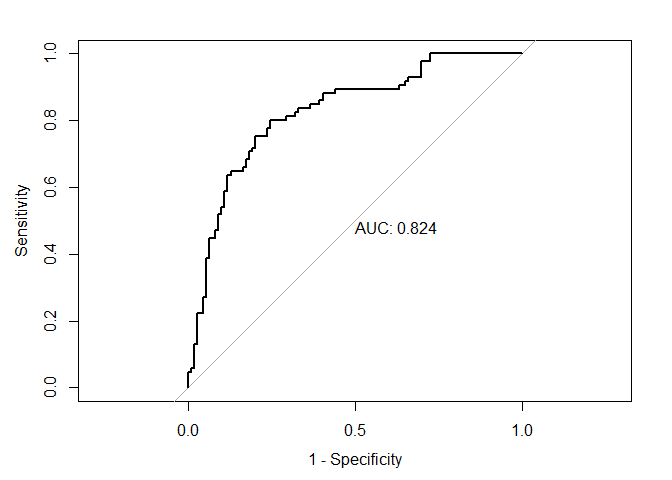

```r
plot.roc(lin_ROC, print.auc=TRUE, legacy.axes=TRUE)
```

AUC = 0.824

### With Radial kernel

```r
trctrl2 <- trainControl(summaryFunction=twoClassSummary,classProbs = TRUE, savePredictions = T, method = "repeatedcv", number = 10, repeats = 10)

svmGrid <- expand.grid(sigma= 2^c(-15,-10, -5, 0), C= 2^c(0:5))

set.seed(300)
svm_Radial <- train(has_hypothyroidism ~., data = training,
              method = "svmRadial",
              trControl = trctrl2,
              preProcess = c("center", "scale"),
              metric = "ROC",
              tuneGrid = svmGrid,
              tuneLength = 10)
print(svm_Radial)
```

```
## Support Vector Machines with Radial Basis Function Kernel
##
## 455 samples
##   7 predictor
##   2 classes: 'No', 'Yes'
##
## Pre-processing: centered (7), scaled (7)
## Resampling: Cross-Validated (10 fold, repeated 10 times)
## Summary of sample sizes: 410, 409, 409, 410, 409, 410, ...
## Resampling results across tuning parameters:
##
##   sigma         C   ROC        Sens       Spec
##   3.051758e-05   1  0.7140677  0.7140462  0.6500
##   3.051758e-05   2  0.7143538  0.7140462  0.6500
##   3.051758e-05   4  0.7149800  0.7140462  0.6500
##   3.051758e-05   8  0.7146454  0.7140462  0.6500
##   3.051758e-05  16  0.7148785  0.7140462  0.6500
##   3.051758e-05  32  0.7149154  0.7140462  0.6500
##   9.765625e-04   1  0.7145892  0.7140462  0.6500
##   9.765625e-04   2  0.7147085  0.7140462  0.6500
##   9.765625e-04   4  0.7166692  0.7171692  0.6500
##   9.765625e-04   8  0.7180308  0.7175538  0.6500
##   9.765625e-04  16  0.7133331  0.7175538  0.6500
##   9.765625e-04  32  0.7082608  0.7175538  0.6500
##   3.125000e-02   1  0.7120162  0.7199385  0.6380
##   3.125000e-02   2  0.7087215  0.7187846  0.6320
##   3.125000e-02   4  0.7122154  0.7211231  0.6260
##   3.125000e-02   8  0.7079869  0.7203538  0.6220
##   3.125000e-02  16  0.7007946  0.7235077  0.6010
##   3.125000e-02  32  0.6975962  0.7317231  0.5875
##   1.000000e+00   1  0.6844792  0.7964000  0.5345
##   1.000000e+00   2  0.6689446  0.7881231  0.5180
##   1.000000e+00   4  0.6491254  0.7835385  0.4540
##   1.000000e+00   8  0.6302077  0.8050308  0.3735
##   1.000000e+00  16  0.6117269  0.8203385  0.3480
##   1.000000e+00  32  0.6070785  0.8415077  0.3040
##
## ROC was used to select the optimal model using the largest value.
## The final values used for the model were sigma = 0.0009765625 and C = 8.
```

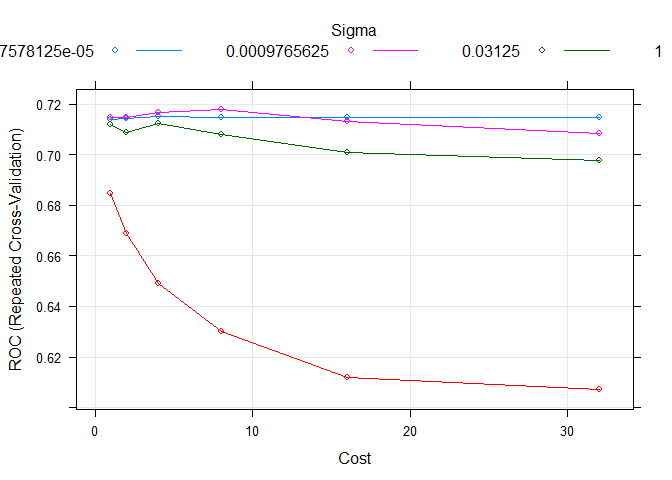

```r
plot(svm_Radial)
```

#### Predicting on test data:

```r
pred_Radial <- predict(svm_Radial, newdata = testing)
print(pred_Radial)
```

```
##   [1] No  No  No  No  No  No  Yes Yes Yes No  No  Yes No  No  No  No  Yes Yes
##  [19] No  Yes No  No  Yes Yes No  No  No  Yes Yes Yes No  Yes No  No  Yes Yes
##  [37] Yes No  Yes No  Yes Yes Yes Yes No  Yes Yes Yes No  No  No  No  No  No
##  [55] Yes No  Yes No  No  No  No  No  No  Yes Yes Yes No  Yes Yes No  Yes No
##  [73] No  Yes Yes Yes No  No  Yes No  No  No  No  No  Yes No  Yes No  No  Yes
##  [91] Yes Yes No  No  Yes Yes Yes Yes No  Yes No  No  Yes Yes No  Yes No  Yes
## [109] Yes No  No  No  Yes No  Yes Yes Yes Yes No  Yes No  No  Yes Yes Yes No
## [127] No  No  No  No  No  No  No  Yes Yes No  No  No  Yes No  Yes No  Yes No
## [145] No  Yes Yes No  Yes No  No  No  No  Yes Yes Yes Yes No  No  No  No  No
## [163] No  No  No  Yes Yes No  No  No  Yes Yes Yes Yes Yes Yes Yes Yes Yes No
## [181] Yes Yes Yes Yes No  No  No  No  Yes No  No  No  No  Yes
## Levels: No Yes
```

#### Displaying Confusion Matrix:

```r
confusionMatrix(pred_Radial, testing$has_hypothyroidism, positive = "Yes")
```

```
## Confusion Matrix and Statistics
##
##           Reference
## Prediction No Yes
##        No  84  21
##        Yes 25  64
##
##                Accuracy : 0.7629
##                  95% CI : (0.6967, 0.8209)
##     No Information Rate : 0.5619
##     P-Value [Acc > NIR] : 4.449e-09
##
##                   Kappa : 0.5209
##
##  Mcnemar's Test P-Value : 0.6583
##
##             Sensitivity : 0.7529
##             Specificity : 0.7706
##          Pos Pred Value : 0.7191
##          Neg Pred Value : 0.8000
##              Prevalence : 0.4381
##          Detection Rate : 0.3299
##    Detection Prevalence : 0.4588
##       Balanced Accuracy : 0.7618
##
##        'Positive' Class : Yes
##
```

Accuracy : 0.7629  
Sensitivity : 0.7529  
Specificity : 0.7706

#### ROC:

```r
rad_Probs <- predict(svm_Radial, testing, type = "prob")
rad_ROC <- roc(testing$has_hypothyroidism, rad_Probs[, "Yes"])
```

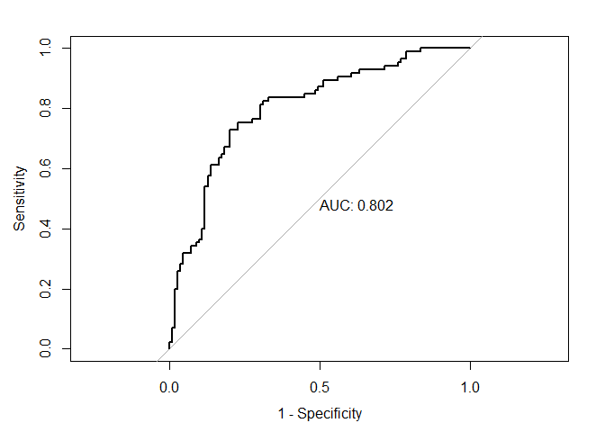

```r
plot.roc(rad_ROC, print.auc=TRUE, legacy.axes=TRUE)
```

AUC = 0.802

### With Polynomial kernel

```r
trctrl3 <- trainControl(summaryFunction=twoClassSummary,classProbs = TRUE, savePredictions = T, method = "cv", number = 5)

svmGrid_poly <- expand.grid(degree = c(2,3),
                            scale = seq(0.1, 1, by = .2),
                            C = c(0.005,0.01, 0.05, 0.1, 0.25, 0.5,
                                  0.75, 1, 1.25, 1.5, 1.75, 2,5))

set.seed(300)
svm_Poly <- train(has_hypothyroidism ~., data = training,
              method = "svmPoly",
              trControl = trctrl3,
              preProcess = c("center", "scale"),
              metric = "ROC",
              tuneGrid = svmGrid_poly,
              tuneLength = 10)
print(svm_Poly)
```

```
## Support Vector Machines with Polynomial Kernel
##
## 455 samples
##   7 predictor
##   2 classes: 'No', 'Yes'
##
## Pre-processing: centered (7), scaled (7)
## Resampling: Cross-Validated (5 fold)
## Summary of sample sizes: 364, 364, 364, 364, 364
## Resampling results across tuning parameters:
##
##   degree  scale  C      ROC        Sens       Spec
##   2       0.1    0.005  0.7077451  0.7098039  0.650
##   2       0.1    0.010  0.7083333  0.7137255  0.650
##   2       0.1    0.050  0.7206863  0.7176471  0.650
```

[output cut: 130 more lines]

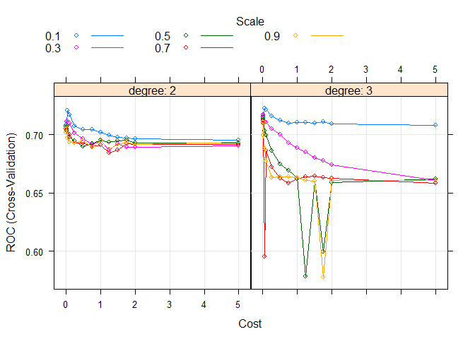

```r
plot(svm_Poly)
```

#### Predicting on test data:

```r
pred_Poly <- predict(svm_Poly, newdata = testing)
print(pred_Poly)
```

```
##   [1] No  No  No  No  Yes No  Yes Yes Yes No  No  Yes No  No  No  No  Yes Yes
##  [19] No  Yes No  No  Yes Yes No  No  No  Yes Yes Yes No  Yes No  No  Yes Yes
##  [37] Yes No  Yes No  Yes Yes Yes Yes No  Yes Yes Yes No  No  No  No  No  Yes
##  [55] Yes No  Yes No  No  No  No  No  No  Yes Yes Yes No  Yes Yes No  Yes No
##  [73] No  Yes Yes Yes No  No  Yes No  No  No  No  No  Yes No  Yes No  No  Yes
##  [91] Yes Yes No  No  Yes Yes Yes Yes No  Yes No  No  Yes Yes No  Yes No  Yes
## [109] Yes No  No  No  Yes No  Yes Yes Yes Yes No  Yes No  No  Yes Yes Yes No
## [127] No  No  No  No  No  No  No  Yes Yes No  No  No  Yes No  Yes No  Yes No
## [145] No  Yes Yes No  Yes No  No  No  No  Yes Yes Yes Yes No  No  No  No  No
## [163] No  No  No  Yes Yes No  No  No  Yes Yes Yes Yes Yes Yes Yes Yes Yes No
## [181] Yes Yes Yes Yes No  No  No  No  Yes No  No  No  No  Yes
## Levels: No Yes
```

#### Displaying Confusion Matrix:

```r
confusionMatrix(pred_Poly, testing$has_hypothyroidism, positive = "Yes")
```

```
## Confusion Matrix and Statistics
##
##           Reference
## Prediction No Yes
##        No  82  21
##        Yes 27  64
##
##                Accuracy : 0.7526
##                  95% CI : (0.6857, 0.8116)
##     No Information Rate : 0.5619
##     P-Value [Acc > NIR] : 2.706e-08
##
##                   Kappa : 0.5013
##
##  Mcnemar's Test P-Value : 0.4705
##
##             Sensitivity : 0.7529
##             Specificity : 0.7523
##          Pos Pred Value : 0.7033
##          Neg Pred Value : 0.7961
##              Prevalence : 0.4381
##          Detection Rate : 0.3299
##    Detection Prevalence : 0.4691
##       Balanced Accuracy : 0.7526
##
##        'Positive' Class : Yes
##
```

Accuracy : 0.7526  
Sensitivity : 0.7529  
Specificity : 0.7523

#### ROC:

```r
pol_Probs <- predict(svm_Poly, testing, type = "prob")
pol_ROC <- roc(testing$has_hypothyroidism, pol_Probs[, "Yes"])
```

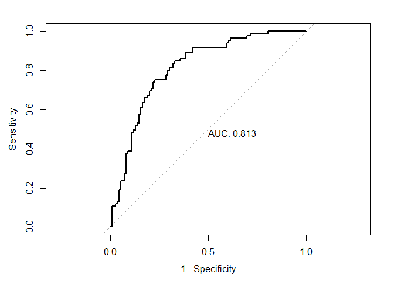

```r
plot.roc(pol_ROC, print.auc=TRUE, legacy.axes=TRUE)
```

AUC = 0.813

# Gradient Boosting

```r
gbmGrid <-  expand.grid(interaction.depth = c(1, 5),
                        n.trees = c(100,250,500,1000,5000),
                        shrinkage = c(0.01, 0.1),
                        n.minobsinnode = c(10,20))

set.seed(300)
gbmFit1 <- train(has_hypothyroidism ~ ., data = training,
                 method = "gbm",
                 metric="ROC",
                 trControl = trctrl2,
                 verbose = FALSE,
                 tuneGrid = gbmGrid)
print(gbmFit1)
```

```
## Stochastic Gradient Boosting
##
## 455 samples
##   7 predictor
##   2 classes: 'No', 'Yes'
##
## No pre-processing
## Resampling: Cross-Validated (10 fold, repeated 10 times)
## Summary of sample sizes: 410, 409, 409, 410, 409, 410, ...
## Resampling results across tuning parameters:
##
##   shrinkage  interaction.depth  n.minobsinnode  n.trees  ROC        Sens
##   0.01       1                  10               100     0.7155269  0.7183385
##   0.01       1                  10               250     0.7157792  0.7359538
##   0.01       1                  10               500     0.7133715  0.7449231
##   0.01       1                  10              1000     0.7048015  0.7379231
##   0.01       1                  10              5000     0.6727308  0.7092769
##   0.01       1                  20               100     0.7148354  0.7183385
##   0.01       1                  20               250     0.7190719  0.7363692
##   0.01       1                  20               500     0.7167154  0.7453231
##   0.01       1                  20              1000     0.7087569  0.7378615
##   0.01       1                  20              5000     0.6775815  0.7132615
##   0.01       5                  10               100     0.7060462  0.7642308
##   0.01       5                  10               250     0.6992700  0.7413846
##   0.01       5                  10               500     0.6874892  0.7320308
##   0.01       5                  10              1000     0.6695108  0.7222615
##   0.01       5                  10              5000     0.6317954  0.6653692
##   0.01       5                  20               100     0.7123854  0.7579231
##   0.01       5                  20               250     0.7053008  0.7335538
##   0.01       5                  20               500     0.6916300  0.7234154
##   0.01       5                  20              1000     0.6763285  0.7136154
##   0.01       5                  20              5000     0.6370046  0.6724154
##   0.10       1                  10               100     0.7024281  0.7375385
##   0.10       1                  10               250     0.6875754  0.7139231
##   0.10       1                  10               500     0.6700700  0.7081077
##   0.10       1                  10              1000     0.6502062  0.6923385
##   0.10       1                  10              5000     0.5933646  0.6338462
##   0.10       1                  20               100     0.7039992  0.7382769
##   0.10       1                  20               250     0.6923454  0.7205846
##   0.10       1                  20               500     0.6764315  0.7097231
```

[output cut: 42 more lines]

```
##   0.4825
##   0.5470
##   0.5255
##   0.5080
##   0.5045
##   0.4925
##   0.5300
##   0.5355
##   0.5180
##   0.5030
##   0.4970
##
## ROC was used to select the optimal model using the largest value.
## The final values used for the model were n.trees = 250, interaction.depth =
##  1, shrinkage = 0.01 and n.minobsinnode = 20.
```

#### Variable Importance

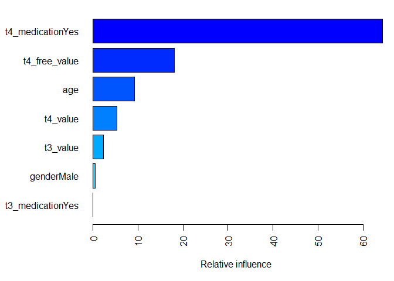

```
##                               var    rel.inf
## t4_medicationYes t4_medicationYes 64.4029446
## t4_free_value       t4_free_value 18.1217636
## age                           age  9.2176559
## t4_value                 t4_value  5.3743552
## t3_value                 t3_value  2.3957773
## genderMale             genderMale  0.4875034
## t3_medicationYes t3_medicationYes  0.0000000
```

```r
par(mar = c(5, 8, 1, 1))
summary(object = gbmFit1, las = 2)
```

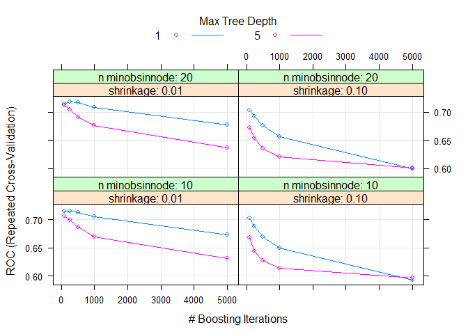

```r
plot(gbmFit1)
```

#### Predicting on test data:

```r
pred_boost <- predict(gbmFit1, newdata = testing)
print(pred_boost)
```

```
##   [1] No  No  No  No  No  No  Yes Yes Yes No  No  Yes No  No  No  No  Yes Yes
##  [19] No  Yes No  No  Yes Yes No  No  No  Yes Yes Yes No  Yes No  No  Yes Yes
##  [37] Yes No  No  No  Yes Yes Yes Yes No  No  No  Yes No  No  No  No  No  No
##  [55] Yes No  Yes No  No  No  No  No  No  Yes Yes Yes No  Yes Yes No  Yes No
##  [73] No  Yes Yes Yes No  No  Yes No  No  No  No  No  Yes No  Yes No  No  No
##  [91] Yes Yes No  No  Yes Yes Yes Yes No  Yes No  No  Yes Yes No  Yes No  Yes
## [109] No  No  No  No  Yes No  Yes Yes Yes Yes No  Yes No  No  Yes Yes Yes No
## [127] No  No  No  No  No  No  No  Yes Yes No  No  No  Yes No  Yes No  Yes No
## [145] No  Yes Yes No  Yes No  No  No  No  Yes Yes Yes Yes No  No  No  No  No
## [163] No  No  No  Yes Yes No  No  No  Yes Yes Yes Yes Yes Yes Yes Yes Yes No
## [181] Yes Yes Yes Yes No  No  No  No  Yes No  No  No  No  Yes
## Levels: No Yes
```

#### Displaying Confusion Matrix:

```r
confusionMatrix(pred_boost, testing$has_hypothyroidism, positive = "Yes")
```

```
## Confusion Matrix and Statistics
##
##           Reference
## Prediction No Yes
##        No  86  24
##        Yes 23  61
##
##                Accuracy : 0.7577
##                  95% CI : (0.6912, 0.8162)
##     No Information Rate : 0.5619
##     P-Value [Acc > NIR] : 1.112e-08
##
##                   Kappa : 0.5073
##
##  Mcnemar's Test P-Value : 1
##
##             Sensitivity : 0.7176
##             Specificity : 0.7890
##          Pos Pred Value : 0.7262
##          Neg Pred Value : 0.7818
##              Prevalence : 0.4381
##          Detection Rate : 0.3144
##    Detection Prevalence : 0.4330
##       Balanced Accuracy : 0.7533
##
##        'Positive' Class : Yes
##
```

Accuracy : 0.7577  
Sensitivity : 0.7176  
Specificity : 0.7890

#### ROC:

```r
boost_Probs <- predict(gbmFit1, testing, type = "prob")
boostROC <- roc(testing$has_hypothyroidism, boost_Probs[, "Yes"])
```

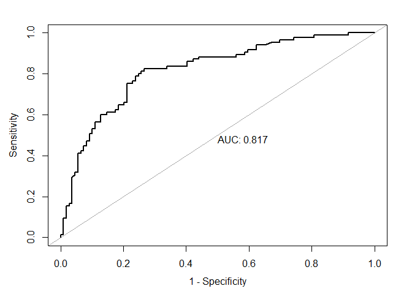

```r
plot.roc(boostROC, asp = NA, print.auc=TRUE, legacy.axes=TRUE)
```

AUC = 0.817

# Random Forest

```r
grid_rf <- expand.grid(.mtry = (1:7))

set.seed(300)
rf <- train(has_hypothyroidism ~., data = training, method = "rf",
                    trControl=trctrl2,
                    metric="ROC",
                    tuneGrid = grid_rf)
print(rf)
```

```
## Random Forest
##
## 455 samples
##   7 predictor
##   2 classes: 'No', 'Yes'
##
## No pre-processing
## Resampling: Cross-Validated (10 fold, repeated 10 times)
## Summary of sample sizes: 410, 409, 409, 410, 409, 410, ...
## Resampling results across tuning parameters:
##
##   mtry  ROC        Sens       Spec
##   1     0.7042550  0.7819846  0.5170
##   2     0.6834596  0.7375385  0.5530
##   3     0.6582369  0.6911692  0.5265
##   4     0.6533331  0.6906923  0.5305
##   5     0.6496469  0.6856769  0.5260
##   6     0.6467565  0.6845231  0.5230
##   7     0.6440162  0.6800769  0.5235
##
## ROC was used to select the optimal model using the largest value.
## The final value used for the model was mtry = 1.
```

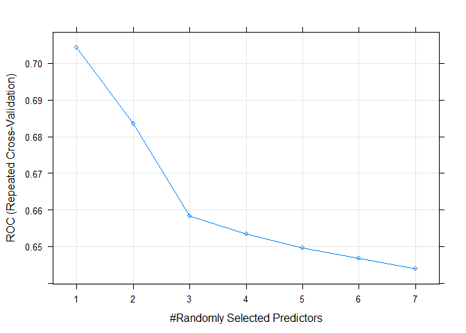

```r
plot(rf)
```

#### Variable Importance

```r
rfImp <- varImp(rf, scale = FALSE)
rfImp
```

```
## rf variable importance
##
##                  Overall
## t4_medicationYes 16.4347
## t4_free_value    11.4457
## age              11.1838
## t3_value         11.1671
## t4_value         10.0989
## genderMale        2.2961
## t3_medicationYes  0.5755
```

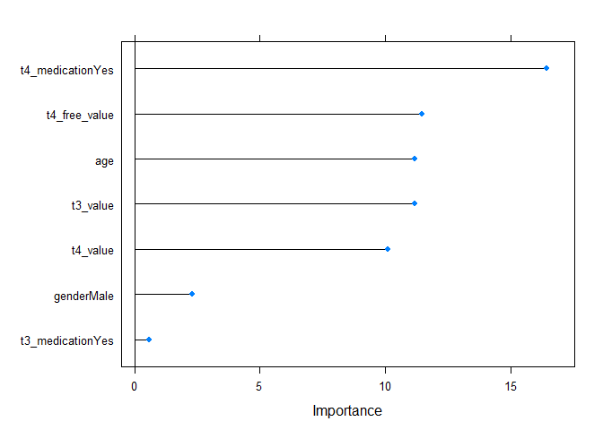

```r
plot(rfImp)
```

#### Predicting on test data:

```r
pred_rf <- predict(rf, newdata = testing)
print(pred_rf)
```

```
##   [1] No  No  No  No  No  No  Yes Yes Yes No  No  Yes No  No  No  No  Yes Yes
##  [19] No  Yes No  No  Yes Yes No  No  No  Yes Yes No  No  Yes No  No  Yes Yes
##  [37] Yes No  No  No  Yes Yes Yes Yes No  No  No  Yes No  No  No  No  No  No
##  [55] Yes No  Yes No  No  No  No  No  No  Yes Yes Yes No  No  No  No  Yes No
##  [73] No  Yes Yes Yes No  No  Yes No  No  No  No  No  Yes No  Yes No  No  No
##  [91] Yes Yes No  No  Yes Yes Yes Yes No  Yes No  No  Yes Yes No  Yes No  Yes
## [109] No  No  No  No  Yes No  No  No  Yes Yes No  Yes No  No  Yes Yes Yes No
## [127] No  No  No  No  No  No  No  Yes Yes No  No  No  No  No  Yes No  Yes No
## [145] No  Yes Yes No  Yes No  No  No  No  Yes Yes Yes Yes No  No  No  No  No
## [163] No  No  No  Yes Yes No  No  No  Yes Yes Yes Yes Yes Yes Yes Yes Yes No
## [181] Yes Yes No  Yes No  No  No  No  Yes No  No  No  No  Yes
## Levels: No Yes
```

#### Dispalying confusion matrix:

```r
confusionMatrix(pred_rf, testing$has_hypothyroidism, positive="Yes")
```

```
## Confusion Matrix and Statistics
##
##           Reference
## Prediction No Yes
##        No  89  28
##        Yes 20  57
##
##                Accuracy : 0.7526
##                  95% CI : (0.6857, 0.8116)
##     No Information Rate : 0.5619
##     P-Value [Acc > NIR] : 2.706e-08
##
##                   Kappa : 0.4922
##
##  Mcnemar's Test P-Value : 0.3123
##
##             Sensitivity : 0.6706
##             Specificity : 0.8165
##          Pos Pred Value : 0.7403
##          Neg Pred Value : 0.7607
##              Prevalence : 0.4381
##          Detection Rate : 0.2938
##    Detection Prevalence : 0.3969
##       Balanced Accuracy : 0.7436
##
##        'Positive' Class : Yes
##
```

Accuracy : 0.7526  
Sensitivity : 0.6706  
Specificity : 0.8165

#### ROC curve:

```r
rfProbs <- predict(rf, testing, type = "prob")
rfROC <- roc(testing$has_hypothyroidism, rfProbs[, "Yes"])
```

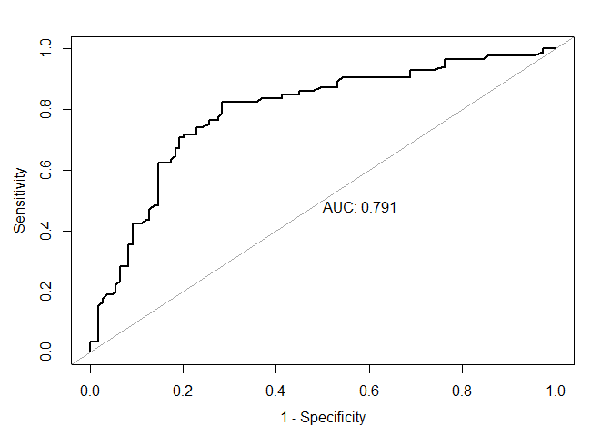

```r
plot.roc(rfROC, asp = NA, print.auc=TRUE, legacy.axes=TRUE)
```

AUC = 0.791

# XGBoost

#### Converting factor variables to numeric for training data

```r
training_num <- training

training_num$gender <- as.numeric(training_num$gender)
training_num$t3_medication <- as.numeric(training_num$t3_medication)
training_num$t4_medication <- as.numeric(training_num$t4_medication)

training_num$gender <- ifelse(training_num$gender == 2, 1, 0)
training_num$t3_medication <- ifelse(training_num$t3_medication == 2, 1, 0)
training_num$t4_medication <- ifelse(training_num$t4_medication == 2, 1, 0)

levels(training_num$has_hypothyroidism) <- c("No", "Yes")
levels(training_num$has_hypothyroidism) <- c("No", "Yes")

head(training_num)
```

```
##     t4_value t3_value t4_free_value age gender t3_medication t4_medication
## 12       4.5      143          0.70   1      0             0             1
## 16       5.6       98          0.80  56      0             0             0
## 27       5.1       85          0.88  52      1             0             0
## 40       7.4       55          1.30  48      0             0             0
## 91       5.6       83          1.70  84      0             0             0
## 120      2.0       35          1.50  64      0             0             1
##     has_hypothyroidism
## 12                 Yes
## 16                  No
## 27                  No
## 40                  No
## 91                 Yes
## 120                Yes
```

#### Converting factor variables to numeric for testing data

```r
testing_num <- testing

testing_num$gender <- as.numeric(testing_num$gender)
testing_num$t3_medication <- as.numeric(testing_num$t3_medication)
testing_num$t4_medication <- as.numeric(testing_num$t4_medication)

testing_num$gender <- ifelse(testing_num$gender == 2, 1, 0)
testing_num$t3_medication <- ifelse(testing_num$t3_medication == 2, 1, 0)
testing_num$t4_medication <- ifelse(testing_num$t4_medication == 2, 1, 0)

levels(testing_num$has_hypothyroidism) <- c("No", "Yes")
levels(testing_num$has_hypothyroidism) <- c("No", "Yes")

head(testing_num)
```

```
##     t4_value t3_value t4_free_value age gender t3_medication t4_medication
## 6       19.8       95           1.5  69      0             0             0
## 46       8.9       56           2.1  74      0             0             0
## 55       5.9       32           0.8  57      0             0             0
## 93       5.9       97           1.5  29      0             0             0
## 101     18.9      363           5.6  20      0             0             0
## 142      8.2      122           1.5  78      0             0             0
##     has_hypothyroidism
## 6                   No
## 46                  No
## 55                  No
## 93                  No
## 101                 No
## 142                 No
```

```r
set.seed(300)

ctrl <- trainControl(method = "repeatedcv",
                     number = 10, repeats = 10,
                     allowParallel = FALSE)

xgb_model <- train(x = data.matrix(training_num[,-8]), y = training_num$has_hypothyroidism,
                  method = "xgbTree",
                  trControl = ctrl,
                  verbose=TRUE)
xgb_model
```

```
## eXtreme Gradient Boosting
##
## 455 samples
##   7 predictor
##   2 classes: 'No', 'Yes'
##
## No pre-processing
## Resampling: Cross-Validated (10 fold, repeated 10 times)
## Summary of sample sizes: 410, 409, 409, 410, 409, 410, ...
## Resampling results across tuning parameters:
##
##   eta  max_depth  colsample_bytree  subsample  nrounds  Accuracy   Kappa
##   0.3  1          0.6               0.50        50      0.6524444  0.2873074
##   0.3  1          0.6               0.50       100      0.6381449  0.2581787
##   0.3  1          0.6               0.50       150      0.6367971  0.2552848
##   0.3  1          0.6               0.75        50      0.6557150  0.2936415
##   0.3  1          0.6               0.75       100      0.6515169  0.2863073
##   0.3  1          0.6               0.75       150      0.6464734  0.2754819
##   0.3  1          0.6               1.00        50      0.6697440  0.3234125
##   0.3  1          0.6               1.00       100      0.6559082  0.2953829
##   0.3  1          0.6               1.00       150      0.6499324  0.2828514
##   0.3  1          0.8               0.50        50      0.6539662  0.2908270
##   0.3  1          0.8               0.50       100      0.6414396  0.2651229
##   0.3  1          0.8               0.50       150      0.6355121  0.2531781
##   0.3  1          0.8               0.75        50      0.6603285  0.3045977
##   0.3  1          0.8               0.75       100      0.6482850  0.2788981
##   0.3  1          0.8               0.75       150      0.6425024  0.2661272
##   0.3  1          0.8               1.00        50      0.6662415  0.3160978
##   0.3  1          0.8               1.00       100      0.6539179  0.2913708
##   0.3  1          0.8               1.00       150      0.6481932  0.2791212
##   0.3  2          0.6               0.50        50      0.6328696  0.2465134
##   0.3  2          0.6               0.50       100      0.6247150  0.2313695
##   0.3  2          0.6               0.50       150      0.6169952  0.2172483
##   0.3  2          0.6               0.75        50      0.6414879  0.2634385
##   0.3  2          0.6               0.75       100      0.6258841  0.2350182
##   0.3  2          0.6               0.75       150      0.6184106  0.2194910
##   0.3  2          0.6               1.00        50      0.6445169  0.2703626
##   0.3  2          0.6               1.00       100      0.6280483  0.2376204
##   0.3  2          0.6               1.00       150      0.6155362  0.2133951
##   0.3  2          0.8               0.50        50      0.6419227  0.2654740
```

[output cut: 73 more lines]

```
##   0.4  3          0.8               0.50       150      0.5886570  0.1625161
##   0.4  3          0.8               0.75        50      0.6099420  0.2019519
##   0.4  3          0.8               0.75       100      0.6051256  0.1947455
##   0.4  3          0.8               0.75       150      0.5923961  0.1700184
##   0.4  3          0.8               1.00        50      0.6203188  0.2236360
##   0.4  3          0.8               1.00       100      0.6012415  0.1867616
##   0.4  3          0.8               1.00       150      0.5925749  0.1697580
##
## Tuning parameter 'gamma' was held constant at a value of 0
## Tuning
##  parameter 'min_child_weight' was held constant at a value of 1
## Accuracy was used to select the optimal model using the largest value.
## The final values used for the model were nrounds = 50, max_depth = 1, eta
##  = 0.3, gamma = 0, colsample_bytree = 0.6, min_child_weight = 1 and subsample
##  = 1.
```

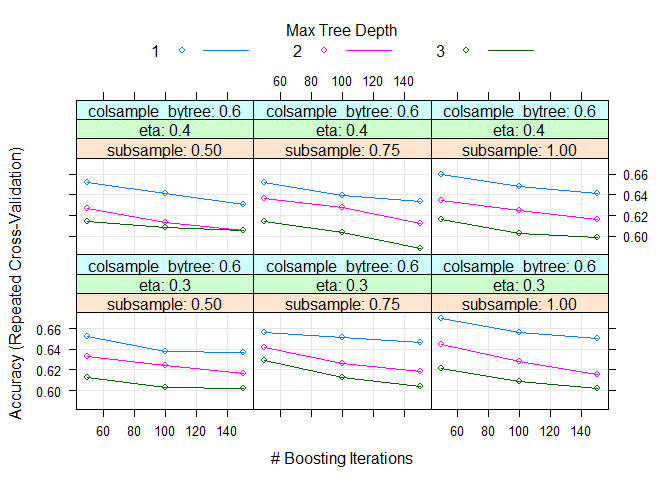

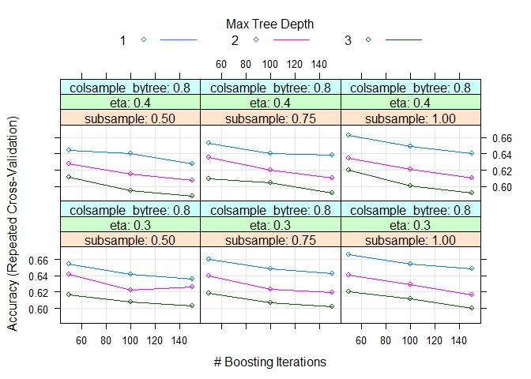

```r
plot(xgb_model)
```

#### Variable Importance

```r
xgbImp <- varImp(xgb_model)
xgbImp
```

```
## xgbTree variable importance
##
##                Overall
## t4_medication 100.0000
## t4_free_value  34.8805
## age            23.6259
## t4_value       11.9606
## t3_value       10.8896
## gender          0.7711
## t3_medication   0.0000
```

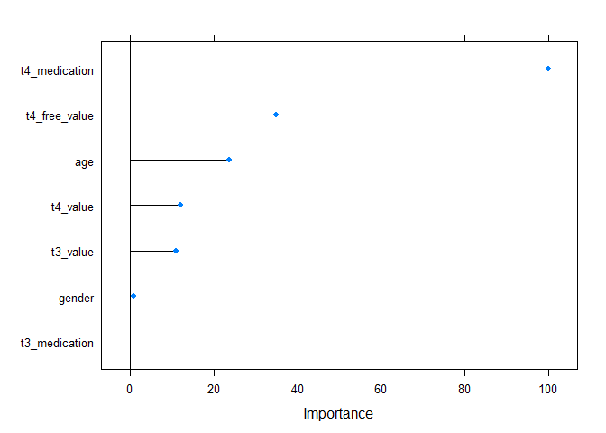

```r
plot(varImp(xgb_model))
```

#### Predicting on test data:

```r
pred_xgb <- predict(xgb_model, newdata = data.matrix(testing_num))
print(pred_xgb)
```

```
##   [1] No  No  No  No  No  No  Yes No  Yes No  No  Yes No  No  No  No  Yes Yes
##  [19] No  Yes No  No  Yes Yes No  No  No  Yes Yes Yes No  Yes No  No  Yes Yes
##  [37] Yes No  No  No  Yes Yes Yes Yes No  No  No  Yes No  No  No  No  No  No
##  [55] Yes No  Yes No  No  No  No  No  No  Yes Yes Yes No  No  Yes No  Yes No
##  [73] No  Yes Yes Yes No  No  Yes No  No  No  No  No  Yes No  Yes No  No  No
##  [91] Yes Yes No  No  Yes Yes Yes No  No  Yes No  No  Yes Yes No  Yes No  Yes
## [109] No  No  No  No  Yes No  No  No  No  Yes Yes No  No  No  Yes Yes Yes No
## [127] No  No  No  No  No  No  No  Yes Yes No  No  No  Yes No  Yes No  Yes No
## [145] No  Yes Yes No  Yes No  No  No  No  Yes Yes Yes Yes No  Yes No  No  No
## [163] No  No  No  Yes Yes No  No  No  Yes Yes Yes Yes Yes Yes Yes Yes Yes No
## [181] No  Yes No  Yes No  No  No  No  Yes No  No  Yes No  Yes
## Levels: No Yes
```

#### Displaying Confusion Matrix:

```r
confusionMatrix(pred_xgb, testing_num$has_hypothyroidism, positive = "Yes")
```

```
## Confusion Matrix and Statistics
##
##           Reference
## Prediction No Yes
##        No  86  30
##        Yes 23  55
##
##                Accuracy : 0.7268
##                  95% CI : (0.6584, 0.7882)
##     No Information Rate : 0.5619
##     P-Value [Acc > NIR] : 1.554e-06
##
##                   Kappa : 0.44
##
##  Mcnemar's Test P-Value : 0.4098
##
##             Sensitivity : 0.6471
##             Specificity : 0.7890
##          Pos Pred Value : 0.7051
##          Neg Pred Value : 0.7414
##              Prevalence : 0.4381
##          Detection Rate : 0.2835
##    Detection Prevalence : 0.4021
##       Balanced Accuracy : 0.7180
##
##        'Positive' Class : Yes
##
```

Accuracy: 0.7268  
Sensitivity: 0.6471  
Specificity: 0.7890

#### ROC:

```r
xgb_Probs <- predict(xgb_model, testing_num, type = "prob")
xgbROC <- roc(testing_num$has_hypothyroidism, xgb_Probs[, "Yes"])
```

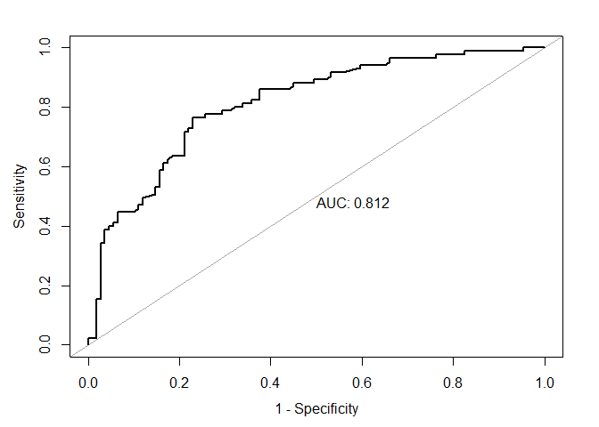

```r
plot.roc(xgbROC, asp = NA, print.auc=TRUE, legacy.axes=TRUE)
```

AUC: 0.812

# Conclusion:

Hence, we observe that, judging by area under the curve (AUC), we get the best results from Logistic Regression (0.831), followed by SVM with linear kernel (0.824), Gradient Boosting (0.817), SVM with polynomial kernel (0.813), XGBoost (0.812), SVM with radial kernel (0.802), and finally Random Forest (0.791).